# Probability

Last updated: 2017-01-24

## Notes

## Readings

## Basics of probability

The probability of an event is the proportion of times the event would occur if a random trial is repeated infinitely under constant conditions.

- Probabilities are proportions.
- Pr[event] is the abbreviation for “the probability of even A occurring.”
  - e.g., \(Pr[heads] = 0.50\)
- The range of probabilities for an event is 0 \(\rightarrow\) 1 (including 0 and 1; \(Pr[event] \in [0, 1]\)).

## Mutually exclusive events: Addition rule

*Mutually exclusive* events are events that are not simultaneously possible due to constraints of physics, biology, development, evolution, etc.

- \(Pr[A~and~B] = 0\)
- Probability of A and B occurring simultaneously.
- e.g., You can't flip a coin heads and tails in one trial
  - \(Pr[heads~and~tails] = 0\)
- \(Pr[A~or~B] = Pr[A] + Pr[B]\)

## Independent events: Multiplication rule

If events are *independent*, then their individual probabilities do no influence each other. The occurrence of one does not alter the probability of the other.

- Successive coin flips
- Successive dice rolls
- Successive roulette wheel spins
- Weekly lottery drawings
- Child sex (in the absence of bad genes)

## Independent events: Multiplication rule

\[Pr[A~and~B] = Pr[A] \times Pr[B]\]

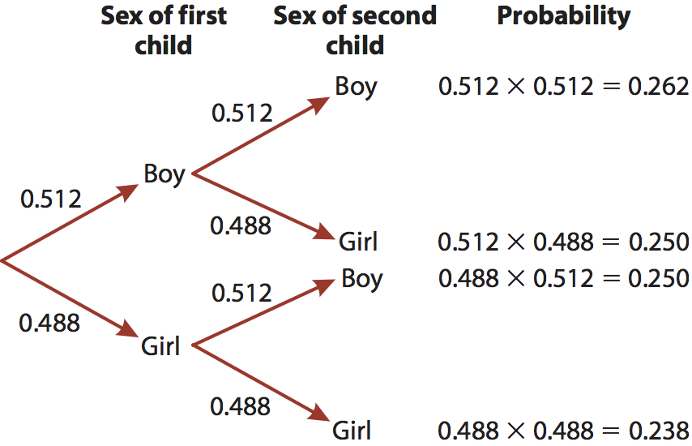

## Should the Packers have tried a 2 point conversion?

[figure not shown]

## Should the Packers have tried a 2 point conversion?

Two-point conversion + win:

- League-wide success rate (since 2003): 431 of 913

Extra point + overtime:

- Extra point success rate (2015 only): 1,131 of 1,199
- Expected winning percentage in overtime (since 2001): Away team has won 110 of 242 games

## Conditional probability

The **conditional probability** of a dependent event is the probability of that even occurring given that another condition or conditions is met.

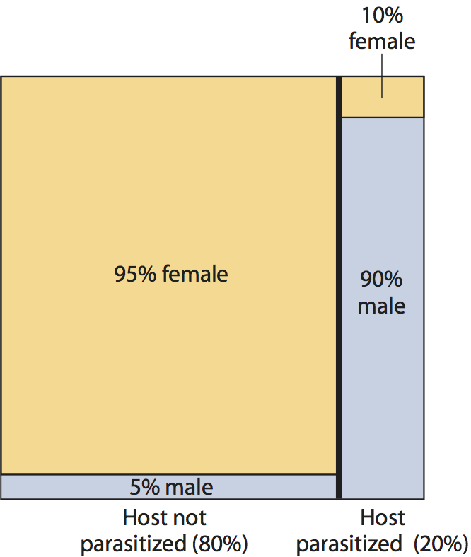

## Conditional probability

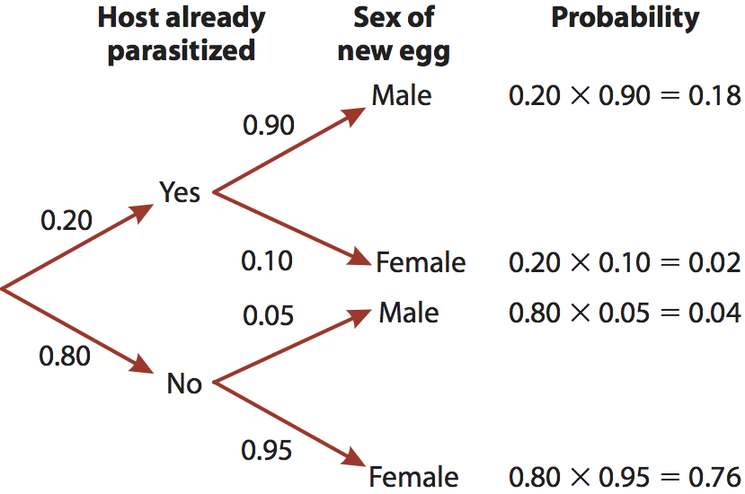

## Bayes' Rule

> "All decisions should be based on evidence, but the best decisions should also be based on previous experience." Stone (2012)

\[Pr[A|B] = \frac{Pr[B|A] \times Pr[A]}{Pr[B]}\]

The conditional probability of \(A\) given \(B\) relies not only on the probability of \(A\), but also of \(B\) and of \(B\) given \(A\).

- Predicting events given prior knowledge of the probability of those events.
- The human brain (usually) works this way in predicting events.

## Bayes' Rule

Suppose that you wake up one day with spots all over your face. The doctor tells you that 90% of people who have smallpox have the same symptoms as you have.

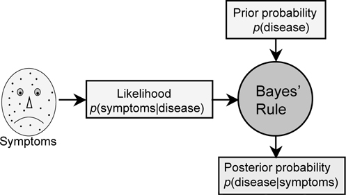

## Bayes' Rule

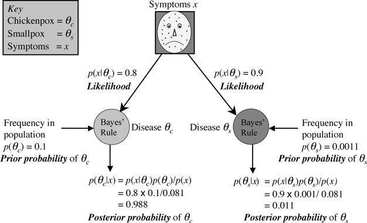

Gentle introduction: http://bit.ly/1nfNZ9p

## Bayes' Rule

Choose a random person off the street and test them for HIV. The test is positive. What is the probability that they actually are HIV+?

1. 95-100%
2. 90-94%
3. 80-89%
4. 65-79%
5. <65%

## Bayes' Rule

If you *have* HIV, the probability that the test is positive is 99.9%

- \(Pr[T|H] = 0.999\)

If you *don't have* HIV, the probability that the test is negative is 99.99%

- \(Pr[T'|H'] = 0.9999\)

Only about 13/100000 people have HIV.

- \(P[H] = 13/100000 = 1.3 \times 10^{-4}\)

## Bayes' Rule

\[Pr[H|T] = \frac{Pr[T|H] \times Pr[H]}{Pr[T]}\]

- Find \(P[H|T]\)

\(Pr[T]\) is the challenge.

## Bayes' Rule

```r
((0.999) * 1.3e-4) /
  ((0.999 * 1.3e-4) + ((1 - 0.9999) * (1 - 1.3e-4)))
```

```
## [1] 0.5650035
```

## Bayes' Rule

Take 100000 people:

- 13 have HIV
- 100000 – 13 = 99987 do not

Of the 13 with HIV:

- 13 * 0.999 = 12.987 test positive
- 13 * 0.001 = 0.013 do not

Of the 99987 who do not:

- 99987 * .0001 = 9.9987 test positive
- 99987 * .9999 = 99977.0013 do not

## Bayes' Rule

So if:

\(Pr(H|T) = \frac{Pr(T|H) \times Pr(H)}{Pr(T)}\)

Then:

\(Pr(H|T) = \frac{0.999 \times (13/100000)}{(12.987 + 9.9987) / 100000} = 0.565\)

Or just \(12.987 / (12.987 + 9.9987)\) because the 100000s cancel out, which is the number of true positives over the total positives.

## Probability thought experiment

A coin is tossed 100 times. Gamblers can bet on the total number of heads that will be thrown. They can do so at any time before or during the game.

- Imagine that you're betting before the game starts. What is your best bet?

Now imagine that you're betting after the coin was already tossed 10 times and came up heads all 10 times.

- What is the best bet now?

## Powerball

Two pools:

1. 69 balls in one pool: Choose 5
2. 26 in the other pool: Choose 1

Number of winning combinations in pool 1 is the **binomial coefficient**

- the number of unique ordered sequences of successes that yield exactly \(m\) successes in \(n\) trials ("n choose m").
- the "successes" can happen in any order

\[\left({n\atop m}\right)=\frac{n!}{m!\left(n-m\right)!}\]

## Powerball

```r
choose(69, 5)
```

```
## [1] 11238513
```

```r
choose(26, 1)
```

```
## [1] 26
```

```r
choose(69, 5) * choose(26, 1)
```

```
## [1] 292201338
```

5 successes from 69 chances \(\times\) 1 success from 26 chances.

- What if the order had to be correct as well?

## More fun with binomial probabilities

My sister has 4 children of which 4 are girls. What is the probability if \(Pr[girl]=0.488\).

```r
0.488 ^ 4
```

```
## [1] 0.05671256
```

```r
dbinom(4, 4, 0.488)
```

```
## [1] 0.05671256
```

## More fun with binomial probabilities

About 10% of people are left handed.

- What is the probability of 0 left handed people in a *sample* of 10?
- What is the probabililty of exactly 1?
- What is the probability of 1 or more?

## Binomial probabilities for Pr[left] = 0.1

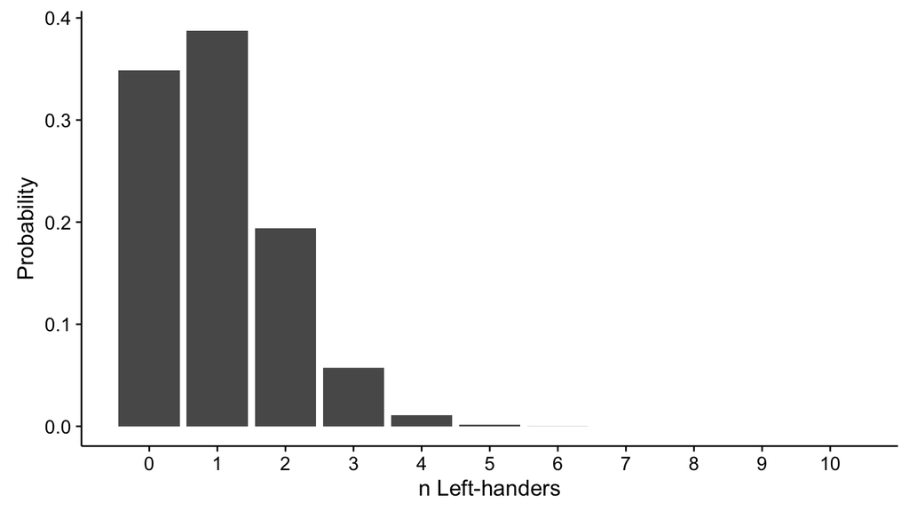

\(n = 7-10\) have very low probabilities.

## Uncertainty

> "In scientific research, measurements are replete with randomness. Extraneous influences contaminate the measurements despite tremendous efforts to limit their intrusion." (Kruschke 2015)

## References

Kruschke, J. K. 2015. *Doing Bayesian Data Analysis: A Tutorial with R, JAGS, and Stan*. Academic Press, Boston, MA.